# PSE-823: Advanced Process Dynamics and Control

## Lecture 3 -- First-Order Systems: Derive, then Code

### (Coughanowr & LeBlanc, Ch. 4-6)

Date: __________

## How today works

- Each idea is **introduced**, then **derived** on the board.
- Then the **code repeats the derivation**, step for step.
- Then the code goes **further** than hand algebra can.
- Full worked derivations: the companion `Derivations` notebook.

The order is: board first, code second. Every code cell on a "Code it" slide has the same step number as the board step it mirrors, so students can lay their notes next to the screen. The derivations are examinable; the code is how we check them and extend them.

## Agenda

**Part A** -- The thermometer: first-order transfer function (Ch. 4)

**Part B** -- Reading $\tau$ from data (Ch. 4, Prob. 4.6)

**Part C** -- The nonlinear tank and linearization (Ch. 5)

**Part D** -- Tanks in series: interaction and transfer lag (Ch. 6)

Tools: `sympy` mirrors the algebra; `numpy`, `scipy`, `python-control` and `matplotlib` build on it.

### Setup (run once)

- Every library from the Python Primer, imported once
- In Colab, uncomment the first line

```python
# !pip install control          # Colab only
import numpy as np
import matplotlib.pyplot as plt
import sympy as sp
import control as ct
from scipy.integrate import solve_ivp
from scipy.optimize import curve_fit
plt.rcParams.update({"font.size": 15})
```

## Part A

### The Thermometer: a First-Order Transfer Function

(Coughanowr & LeBlanc, Ch. 4)

### Introduce -- the mercury thermometer (Sec. 4.1)

- Bulb at temperature $y(t)$, sitting in a bath at $x(t)$.
- The bath changes. **How does the reading follow it?**
- Assumptions: all resistance in the film ($h$), bulb uniform, glass holds no heat, no expansion.

*Textbook figure: Coughanowr Fig. 4-1a (cross-section of thermometer bulb).*

Motivate: a sensor is a process too. Whatever a controller "sees" has already been filtered by the sensor's own dynamics. Emphasise the assumptions: they are what make the model first order.

### Derive 1/4 -- unsteady-state energy balance

Rate in $-$ rate out $=$ rate of accumulation:

$$hA\,(x-y) \;-\; 0 \;=\; mC\,\frac{dy}{dt}$$

$A$: bulb surface area, $m$: mass of mercury, $C$: heat capacity.

### Derive 2/4 -- deviation variables

Before $t=0$ the bulb is at steady state: $hA(x_s-y_s)=0$.

Subtract, and define $X = x-x_s$, $\;Y = y-y_s$:

$$hA\,(X-Y) = mC\,\frac{dY}{dt}, \qquad Y(0)=0$$

Why deviation variables: they make the initial condition zero, so the Laplace transform of dY/dt is just sY(s). That is what lets a clean ratio Y(s)/X(s) exist at all.

### Derive 3/4 -- Laplace transform

Transform both sides, using $\mathcal{L}\{dY/dt\} = sY(s) - Y(0)$:

$$hA\,[X(s)-Y(s)] = mC\,s\,Y(s)$$

### Derive 4/4 -- the transfer function

Collect $Y(s)$ and divide by $X(s)$:

$$\frac{Y(s)}{X(s)} = \frac{1}{\tau s+1}, \qquad \tau = \frac{mC}{hA}$$

General form: $K_p/(\tau s+1)$, gain $K_p$, time constant $\tau$.

Five-step recipe (Sec. 4.1): balance -> linearize if needed -> deviation variables -> Laplace -> ratio output/input. Ex. 4.1: Y/X = 2/(s + 1/3) = 6/(3s + 1), so tau = 3 and Kp = 6. Always rearrange to a 1 in the denominator before reading off tau.

### Code it -- the same four steps in SymPy

- SymPy does algebra with **symbols**, as on the board
- Each cell below carries the **step number** it mirrors
- Nothing new is derived; the computer checks our algebra

### Code 1-2/4 -- the balance, in deviation variables

- `sp.Function` declares an unknown function of $t$
- `sp.Eq(left, right)` is an **equation**, not an assignment

```python
t, s = sp.symbols("t s", positive=True)
h, A, m, C = sp.symbols("h A m C", positive=True)
X, Y = sp.Function("X"), sp.Function("Y")   # deviation vars

# hA (X - Y) = mC dY/dt
balance = sp.Eq(h*A*(X(t) - Y(t)), m*C*Y(t).diff(t))
balance
```

$\displaystyle A h \left(X{\left(t \right)} - Y{\left(t \right)}\right) = C m \frac{d}{d t} Y{\left(t \right)}$

**Code walkthrough.** `sp.symbols(..., positive=True)` creates the symbols and tells SymPy they are positive, which lets it simplify later. `sp.Function` declares X and Y as unknown functions of time (deviation variables). `sp.Eq` builds the equation of Derive 1/4-2/4: hA(X - Y) = mC dY/dt, where `Y(t).diff(t)` is dY/dt. The last line displays the equation as typeset math, so it can be checked against the board.

### Code 3/4 -- Laplace transform of each side

- `sp.laplace_transform` knows the derivative rule
- Look for the $-Y(0)$ term in the output

```python
lhs = sp.laplace_transform(balance.lhs, t, s, noconds=True)
rhs = sp.laplace_transform(balance.rhs, t, s, noconds=True)
rhs                          # C m (s L{Y} - Y(0))
```

$\displaystyle C m \left(s \mathcal{L}_{t}\left[Y{\left(t \right)}\right]\left(s\right) - Y{\left(0 \right)}\right)$

**Code walkthrough.** `sp.laplace_transform(expr, t, s, noconds=True)` transforms each side of the balance separately. The left side is linear, so it becomes hA(L{X} - L{Y}). The right side becomes mC(s L{Y} - Y(0)): SymPy applied the derivative rule of Eq. 2.6 itself. Displaying `rhs` shows the -Y(0) term -- the one deviation variables are about to remove.

### Code 3/4 (cont.) -- tidy up: $Y(0)=0$

- Rename the transforms to plain symbols $X_s$, $Y_s$
- Set $Y(0)=0$, exactly as deviation variables promised

```python
Xs, Ys = sp.symbols("X_s Y_s")
rename = {sp.LaplaceTransform(X(t), t, s): Xs,
          sp.LaplaceTransform(Y(t), t, s): Ys,
          Y(0): 0}                         # deviation variable
eq_s = sp.Eq(lhs.subs(rename), rhs.subs(rename))
eq_s                                       # hA (Xs - Ys) = mC s Ys
```

$\displaystyle A h \left(X_{s} - Y_{s}\right) = C Y_{s} m s$

**Code walkthrough.** The transformed expressions contain objects such as LaplaceTransform(Y(t), t, s); `rename` maps them to plain symbols X_s and Y_s, and also sets Y(0) = 0 (deviation variables start at zero). `.subs(rename)` applies all three replacements at once. The result, hA(X_s - Y_s) = mC s Y_s, is Derive 3/4 on the board.

### Code 4/4 -- solve for $Y_s/X_s$

- `sp.solve(eq, Ys)` isolates $Y_s$; divide by $X_s$
- Then substitute $mC = \tau hA$ to reach standard form

```python
G = sp.solve(eq_s, Ys)[0] / Xs     # Y(s) / X(s)
print(sp.simplify(G))              # A h / (A h + C m s)

tau = sp.symbols("tau", positive=True)
sp.simplify(G.subs(m, tau*h*A/C))  # 1 / (tau s + 1)
```

```
A*h/(A*h + C*m*s)
```

$\displaystyle \frac{1}{s \tau + 1}$

**Code walkthrough.** `sp.solve(eq_s, Ys)[0]` isolates Y_s; dividing by X_s gives the transfer function. The first print shows A h/(A h + C m s). The second line substitutes m = tau hA/C (the definition of tau rearranged) and simplifies: 1/(tau s + 1), Derive 4/4. This is the whole derivation, done by the computer in four cells -- point at each cell and the matching board step.

### Introduce -- the step response

- Now **use** the transfer function: plunge the thermometer into a hotter bath.
- A step of size $A$ in the bath temperature: $X(s) = A/s$.
- **Example 4.2:** $\tau = 0.1$ min, reading 90 F, bath at 100 F. When does it read **98 F**?

### Derive 1/3 -- output in the $s$-domain

Multiply the input by the transfer function:

$$Y(s) = \frac{A}{s}\cdot\frac{1}{\tau s+1} = \frac{A}{s} - \frac{A\tau}{\tau s+1}$$

(partial fractions, cover-up rule)

### Derive 2/3 -- invert

Each term is in the table:

$$Y(t) = A\left(1 - e^{-t/\tau}\right) \qquad \text{(Eq. 4.15)}$$

At $t=\tau$: $Y/A = 1-e^{-1} = 0.632$.

### Derive 3/3 -- Example 4.2 by hand

$A = 10$ F, $\tau = 0.1$ min, want $Y = 98-90 = 8$ F:

$$8 = 10\left(1-e^{-t/0.1}\right) \;\Rightarrow\; t = 0.1\ln 5 = 0.161 \text{ min}$$

### Code 1/3 -- $Y(s)$ and partial fractions

- Build $Y(s) = X(s)\,G(s)$ with the step $X(s) = A/s$
- `sp.apart` does the partial fractions

```python
A = sp.symbols("A", positive=True)   # now: step size
Y_s = (A / s) / (tau*s + 1)          # X(s) G(s)
sp.apart(Y_s, s)                     # A/s - A tau/(tau s + 1)
```

$\displaystyle - \frac{A \tau}{s \tau + 1} + \frac{A}{s}$

**Code walkthrough.** `A` is redefined as the step size. Y(s) = X(s) G(s) with X(s) = A/s. `sp.apart(Y_s, s)` splits it into partial fractions in s: A/s - A tau/(tau s + 1), the cover-up result of Derive 1/3.

### Code 2/3 -- invert to the time domain

- `sp.inverse_laplace_transform` replaces the table
- Then ask the formula for the fraction complete at $t = n\tau$

```python
y_step = sp.inverse_laplace_transform(Y_s, s, t)
print(y_step)                        # A (1 - exp(-t/tau))

for n in [1, 2, 3, 4, 5]:
    frac = (y_step / A).subs(t, n*tau)
    print(f"t = {n} tau: {float(frac):.3f} of final value")
```

```
A*(1 - exp(-t/tau))
t = 1 tau: 0.632 of final value
t = 2 tau: 0.865 of final value
t = 3 tau: 0.950 of final value
t = 4 tau: 0.982 of final value
t = 5 tau: 0.993 of final value
```

**Code walkthrough.** `inverse_laplace_transform` returns A(1 - exp(-t/tau)), Eq. 4.15. The loop then evaluates the fraction complete, y/A, at t = n tau by substitution: 0.632, 0.865, 0.950, 0.982, 0.993. These are the rules worth memorising: 63.2% at one tau, 95% at three, 99.3% at five.

### Code 3/3 -- Example 4.2 with numbers

- `sp.lambdify` turns the formula into a NumPy function
- Evaluate on a time grid; find the first time above 98 F

```python
y_num = sp.lambdify((t, tau, A), y_step, "numpy")

tt = np.linspace(0, 0.6, 601)          # min
reading = 90 + y_num(tt, 0.1, 10)      # 90 F + deviation
i98 = np.argmax(reading >= 98)         # first index at 98 F
print(f"98 F at t = {tt[i98]:.3f} min  (hand: 0.161)")
```

```
98 F at t = 0.161 min  (hand: 0.161)
```

**Code walkthrough.** `sp.lambdify((t, tau, A), y_step, "numpy")` converts the symbolic formula into a fast NumPy function of three arguments. `tt` is a grid of 601 times from 0 to 0.6 min; the reading is 90 F plus the deviation for tau = 0.1 min and a 10 F step. `np.argmax(reading >= 98)` returns the first index where the condition is True. Prints 98 F at t = 0.161 min, the hand answer of Example 4.2.

### Build on it -- plotting the response, one piece at a time

- The derivation is done. Now we **draw** it.
- Same recipe as the Primer: curve, then labels, then guides.

### Plot 1/3 -- the curve

- `fig, ax = plt.subplots(...)` gives a figure we can control
- `ax.plot(x, y)` draws one curve

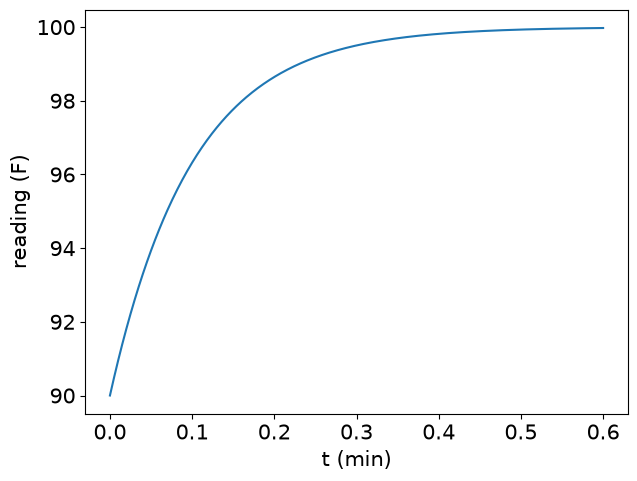

```python
fig, ax = plt.subplots(figsize=(7, 5.25))
ax.plot(tt, reading)                  # thermometer reading
ax.set_xlabel("t (min)")
ax.set_ylabel("reading (F)")
plt.show()
```

**Code walkthrough.** The minimal plot: create a figure of 4:3 proportions, draw one curve, label the axes, show it. The curve is the thermometer reading rising from 90 F toward 100 F.

### Plot 2/3 -- mark the numbers we derived

- `axhline` / `axvline`: horizontal and vertical guides
- 63.2% of the change at $t = \tau$; 98 F at $t = 0.161$ min

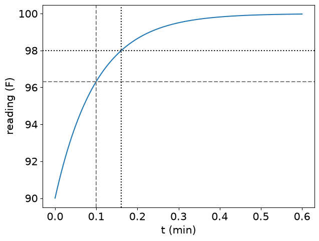

```python
fig, ax = plt.subplots(figsize=(7, 5.25))
ax.plot(tt, reading)
ax.axvline(0.1, ls="--", c="gray")      # t = tau
ax.axhline(90 + 6.32, ls="--", c="gray") # 63.2% of 10 F
ax.axhline(98, ls=":", c="k")           # target reading
ax.axvline(tt[i98], ls=":", c="k")      # time to reach it
ax.set(xlabel="t (min)", ylabel="reading (F)")
plt.show()
```

**Code walkthrough.** Same curve plus four guide lines. `axvline(0.1)` marks t = tau and `axhline(96.32)` marks 63.2% of the 10 F change; they cross on the curve. The dotted pair marks 98 F and the time found in Code 3/3; they also cross on the curve. The plot verifies both derived numbers.

### Plot 3/3 -- effect of $\tau$ (cf. Fig. 4-13)

- Loop over three values of $\tau$; one call per curve
- `label=` plus `ax.legend()` gives the key

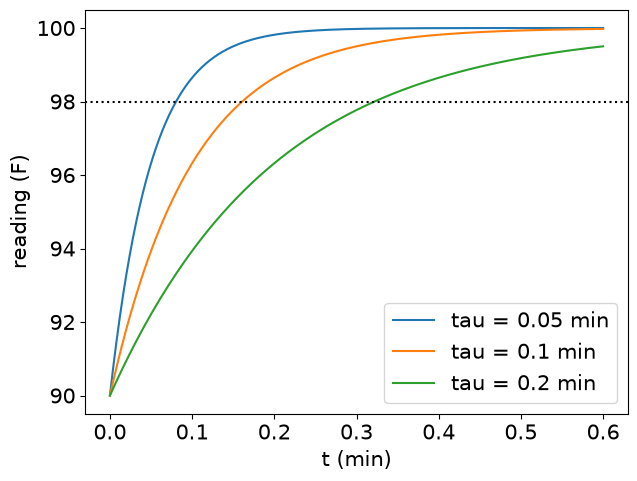

```python
fig, ax = plt.subplots(figsize=(7, 5.25))
for tau_i in [0.05, 0.1, 0.2]:               # min
    ax.plot(tt, 90 + y_num(tt, tau_i, 10),
            label=f"tau = {tau_i} min")
ax.axhline(98, ls=":", c="k")
ax.set(xlabel="t (min)", ylabel="reading (F)")
ax.legend(loc="lower right")
plt.show()
```

**Code walkthrough.** The `for` loop draws one curve per time constant, each with a `label`, and `ax.legend` builds the key. Smaller tau rises faster; every curve reaches 63.2% of the step at its own tau (cf. Fig. 4-13).

### Build on it -- the same model in `python-control`

- `ct.tf(num, den)`: coefficients, highest power of $s$ first
- `step_response` needs **no** algebra -- and matches ours

```python
G_th = ct.tf([1], [0.1, 1])              # 1 / (0.1 s + 1)
print("pole:", ct.poles(G_th))           # -1/tau = -10

resp = ct.step_response(10 * G_th, tt)   # 10 F step
gap = np.abs(90 + resp.outputs - reading).max()
print(f"max |python-control - formula| = {gap:.1e} F")
```

```
pole: [-10.+0.j]
max |python-control - formula| = 7.1e-14 F
```

**Code walkthrough.** `ct.tf([1], [0.1, 1])` builds 1/(0.1 s + 1) from coefficient lists, highest power of s first. `ct.poles` prints -10: the pole sits at -1/tau. `ct.step_response(10 * G_th, tt)` simulates a 10 F step with no algebra at all; `.outputs` is the response array. The largest gap to the derived formula is printed: below 1e-13 F, i.e. round-off. From here on python-control does the inversion for us.

### Introduce -- a sinusoidal bath (Example 4.3)

- Same thermometer, $\tau = 0.1$ min.
- Bath oscillates $\pm 2$ F about 100 F at $\omega = 20$ rad/min.
- Does the reading show the **full** swing? Is it **in step**?

### Derive 1/2 -- transform and split

$X(t) = A\sin\omega t \;\Rightarrow\; X(s) = A\omega/(s^2+\omega^2)$:

$$Y(s) = \frac{A\omega}{(s^2+\omega^2)(\tau s+1)}$$

Partial fractions: one real pole, one complex pair.

### Derive 2/2 -- the ultimate (long-time) response

The $e^{-t/\tau}$ term dies out, leaving (Eq. 4.28):

$$Y(t) \to \frac{A}{\sqrt{1+\omega^2\tau^2}}\sin(\omega t+\phi), \quad \phi = -\tan^{-1}(\omega\tau)$$

### Code 1/2 -- partial fractions and inverse

- Same two calls as the step: `apart`, then invert
- Exact numbers: `sp.Rational(1, 10)` keeps $\tau$ as a fraction

```python
w = 20                                      # rad/min
Y_sin = 2*w / ((s**2 + w**2) * (sp.Rational(1, 10)*s + 1))
print(sp.apart(Y_sin, s))                   # three terms

y_sin = sp.inverse_laplace_transform(Y_sin, s, t)
y_sin                                       # decay + sine + cosine
```

```
-4*(s - 10)/(5*(s**2 + 400)) + 4/(5*(s + 10))
```

$\displaystyle \frac{2 \sin{\left(20 t \right)}}{5} - \frac{4 \cos{\left(20 t \right)}}{5} + \frac{4 e^{- 10 t}}{5}$

**Code walkthrough.** `w = 20` rad/min. Y(s) = A w/((s^2 + w^2)(tau s + 1)) with A = 2 F and tau = 1/10 as an exact fraction, so SymPy keeps exact numbers. `apart` prints three terms: one for the real pole at -10 and two for the complex pair +/- 20j. The inverse is a decaying exponential plus a sine and a cosine at the bath frequency.

### Code 2/2 -- bath versus thermometer (cf. Fig. 4-18)

- `lambdify` again, then plot input and output together
- Left of the dotted line: transient. Right: the ultimate response

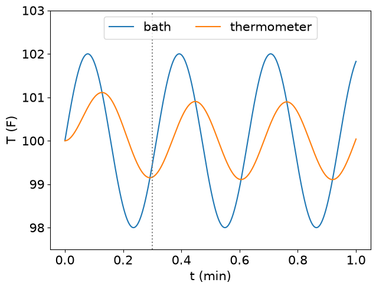

```python
f_sin = sp.lambdify(t, y_sin, "numpy")
tt = np.linspace(0, 1.0, 2001)                # min
fig, ax = plt.subplots(figsize=(7, 5.25))
ax.plot(tt, 100 + 2*np.sin(20*tt), label="bath")
ax.plot(tt, 100 + f_sin(tt), label="thermometer")
ax.axvline(0.3, ls=":", c="gray")             # ~3 tau
ax.set(xlabel="t (min)", ylabel="T (F)", ylim=(97.5, 103))
ax.legend(loc="upper center", ncol=2)
plt.show()
```

### Build on it -- sweep the frequency

- Amplitude ratio for **every** $\omega$ at once: one NumPy line
- Log axes: a preview of the **Bode plot** (Ch. 15)

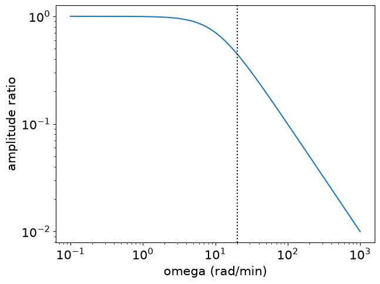

```python
w = np.logspace(-1, 3, 200)                # rad/min
AR = 1 / np.sqrt(1 + (w * 0.1)**2)         # Eq. 4.28
fig, ax = plt.subplots(figsize=(7, 5.25))
ax.loglog(w, AR)
ax.axvline(20, ls=":", c="k")              # Example 4.3
ax.set(xlabel="omega (rad/min)", ylabel="amplitude ratio")
plt.show()
```

**Code walkthrough.** `np.logspace(-1, 3, 200)` gives 200 frequencies spaced evenly on a log scale from 0.1 to 1000 rad/min. Eq. 4.28 is evaluated for all of them in one vectorized line. `loglog` uses log axes on both sides. The curve is flat at 1 for slow baths and falls like 1/(omega tau) for fast ones; the corner is at omega = 1/tau = 10 rad/min. A first-order system is a low-pass filter: this is Ch. 15 (Lecture 7) in miniature.

### Your Turn (10 min)

**Probs. 4.9-4.10.** Thermometer, $\tau = 1$ min, reads 50 C. At $t=0$ it goes into a 100 C bath; at $t=1.5$ min it is moved to a 75 C bath.

1. By hand: the reading at $t=1.2$ min.
2. By hand: the **maximum** reading, and the reading at $t=20$ min.
3. Read the code: what does `50 + y_num(1.2, 1.0, 50)` print?

(1) y = 100 - 50 e^{-1.2} = 84.94 C. (2) At t = 1.5: y = 100 - 50 e^{-1.5} = 88.84 C. After the move the reading decays toward 75: y = 75 + 13.84 e^{-(t-1.5)}. So the maximum is 88.84 C, at the moment of transfer; at t = 20 min, y = 75.00 C. (3) Prints 84.94... -- the same as (1): y_num evaluates A(1 - e^(-t/tau)) with t = 1.2, tau = 1, A = 50. Common slip: thinking the reading keeps rising after the move (it was below 100, above 75 -> falls immediately). Full piecewise simulation with forced_response is in the Derivations notebook.

### Check -- cold-call

In Example 4.3, **halve** $\tau$.

Does the lag *in minutes* between bath and thermometer peaks go up or down? Answer from the formula -- then rerun the sweep.

phi = atan(w tau) = atan(1) = 45 deg; lag = phi/w = 0.785/20 = 0.039 min, down from 0.055 min. Smaller tau = faster sensor = less attenuation and less lag. Change 0.1 -> 0.05 in the sweep cell: the corner moves right.

## Part B

### Reading $\tau$ from Data

(Coughanowr & LeBlanc, Ch. 4, Prob. 4.6)

### Introduce -- $h$ is never known

- $\tau = mC/hA$, but in practice $h$ is **unknown**.
- So: **measure** the response, and infer $\tau$ from it.
- **Prob. 4.6.** Thermometer at 75 F plunged into a 400 F oil bath; readings taken over 30 s.
- First time in this course a model is **learned from data**.

### Derive 1/3 -- normalize the data

From Part A, with a step of $A = 400-75 = 325$ F:

$$\frac{Y}{A} = \frac{y-75}{325} = 1 - e^{-t/\tau}$$

Every reading becomes a fraction between 0 and 1.

### Derive 2/3 -- two ways to read $\tau$

**(a)** At $t=\tau$, $Y/A = 0.632$: interpolate the table.

**(b)** Take logs -- a straight line through the origin:

$$z \equiv \ln\!\left(1-\frac{Y}{A}\right) = -\frac{t}{\tau}$$

### Derive 3/3 -- least squares on the line

Minimize $\sum_i (z_i + k\,t_i)^2$ over $k = 1/\tau$:

$$\frac{d}{dk}\sum_i (z_i + k t_i)^2 = 0 \;\Rightarrow\; k = -\frac{\sum_i t_i z_i}{\sum_i t_i^2}$$

One-parameter least squares with no intercept, done by hand: expand, differentiate, set to zero. This is the same normal equation as linear regression, with one feature and no bias term.

### Code 1/3 -- the data, normalized

- Two arrays straight from the book's table
- One vectorized line per derivation step

```python
t_d = np.array([0, 1, 2.5, 5, 8, 10, 15, 30])            # s
y_d = np.array([75, 107, 140, 205, 244, 282, 328, 385])  # F
frac = (y_d - 75) / 325                   # Y/A
for ti, f in zip(t_d, frac):
    print(f"t = {ti:5.1f} s    Y/A = {f:.3f}")
```

```
t =   0.0 s    Y/A = 0.000
t =   1.0 s    Y/A = 0.098
t =   2.5 s    Y/A = 0.200
t =   5.0 s    Y/A = 0.400
t =   8.0 s    Y/A = 0.520
t =  10.0 s    Y/A = 0.637
t =  15.0 s    Y/A = 0.778
t =  30.0 s    Y/A = 0.954
```

**Code walkthrough.** The two arrays are the Prob. 4.6 table: time in seconds and reading in F. `frac` normalizes every reading in one line: (y - 75)/325 = Y/A. The loop prints the eight fractions, from 0.000 to 0.954 -- every reading becomes "fraction of the way to the oil temperature".

### Code 2/3 -- (a) interpolate the 63.2% crossing

- `np.interp(x, xp, fp)`: linear interpolation, as by hand
- Here we ask: at what $t$ does $Y/A$ reach 0.632?

```python
tau_a = np.interp(0.632, frac, t_d)       # frac is increasing
print(f"(a) tau = {tau_a:.1f} s")
```

```
(a) tau = 9.9 s
```

**Code walkthrough.** `np.interp(x, xp, fp)` interpolates linearly: it finds where the increasing `frac` array reaches 0.632 and returns the matching time, exactly as one would read a table by hand. Prints (a) tau = 9.9 s (0.632 falls just below the t = 10 s reading of 0.637).

### Code 3/3 -- (b) the log line, and its slope

- `np.log` on the whole array: every $z_i$ at once
- Slope from the formula we just derived

```python
z = np.log(1 - frac)                       # z = -t / tau
k = -np.sum(t_d * z) / np.sum(t_d**2)      # least-squares slope
print(f"(b) tau = {1/k:.1f} s")
```

```
(b) tau = 9.9 s
```

**Code walkthrough.** `np.log(1 - frac)` turns every fraction into z = -t/tau (Derive 2/3b). The slope k is the least-squares formula of Derive 3/3, written with two `np.sum` calls. Prints (b) tau = 9.9 s. Note `np.log(1 - 1.0)` would be -inf: a reading equal to the bath temperature cannot be used.

### Plot -- is the log line really straight?

- If the model is first order, the dots fall on one line
- Curvature would mean the model form is wrong

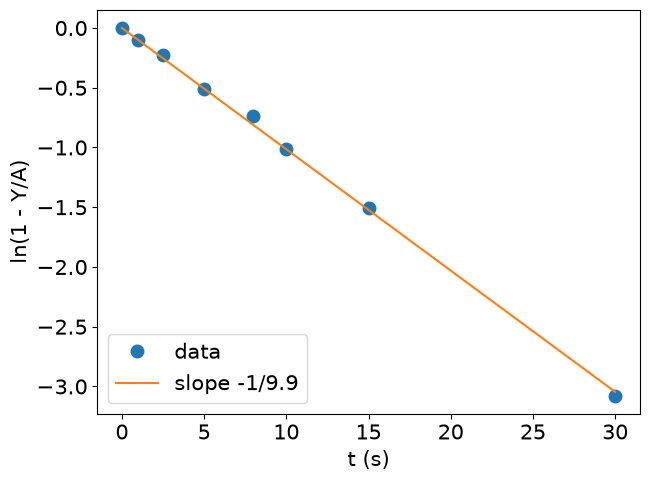

```python
fig, ax = plt.subplots(figsize=(7, 5.25))
ax.plot(t_d, z, "o", ms=9, label="data")
ax.plot(t_d, -k * t_d, label=f"slope -1/{1/k:.1f}")
ax.set(xlabel="t (s)", ylabel="ln(1 - Y/A)")
ax.legend(loc="lower left")
plt.show()
```

**Code walkthrough.** Dots are the eight z values; the line is z = -k t through the origin. If the system were not first order the dots would curve away from any straight line. The last point (t = 30 s, Y/A = 0.954) dominates a no-intercept fit on the log scale, and the log inflates noise near Y/A = 1 -- one reason to fit the raw curve directly, next.

### Build on it -- fit the raw curve with `curve_fit`

- Fit $y = 75 + 325(1-e^{-t/\tau})$ directly: no log trick
- `curve_fit` also returns an **uncertainty** for $\tau$

```python
def model(t, tau):
    return 75 + 325 * (1 - np.exp(-t / tau))

popt, pcov = curve_fit(model, t_d, y_d, p0=[5.0])
tau_fit, tau_se = popt[0], np.sqrt(pcov[0, 0])
print(f"tau = {tau_fit:.2f} +/- {tau_se:.2f} s")
print("residuals (F):", np.round(y_d - model(t_d, tau_fit), 1))
```

```
tau = 10.19 +/- 0.19 s
residuals (F): [ 0.   1.6 -5.7  3.9 -7.8  3.8  2.5  2.1]
```

### Plot -- data and fitted model

- Dots: the book's measurements. Line: the fitted model
- All eight points used at once

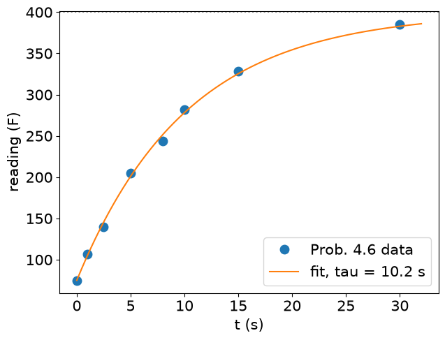

```python
tt = np.linspace(0, 32, 300)
fig, ax = plt.subplots(figsize=(7, 5.25))
ax.plot(t_d, y_d, "o", ms=9, label="Prob. 4.6 data")
ax.plot(tt, model(tt, tau_fit), label=f"fit, tau = {tau_fit:.1f} s")
ax.axhline(400, ls=":", c="gray")
ax.set(xlabel="t (s)", ylabel="reading (F)")
ax.legend(loc="lower right")
plt.show()
```

**Code walkthrough.** The fitted model evaluated on a fine grid (line) over the book's data (dots), with the 400 F oil temperature as a dotted line. All eight points are used at once -- the fit is a compromise among them.

### Read the output

`curve_fit` minimizes $\sum_i (y_i-\hat y_i)^2$ -- the **same objective** as regression in machine learning.

- Physics fixes the model's **form**; only $\tau$ is learned.
- Small residuals, no trend: first order is adequate.
- The $\pm$ uncertainty is something no hand estimate gives.

### Your Turn (8 min)

1. By hand: use only the points at $t=5$ and $t=15$ s to get the slope of the log line, and so $\tau$.
2. Read the code: what is `1 / k2` (to one decimal)?

```
k2 = -np.sum(t_d[[3, 6]] * z[[3, 6]]) / np.sum(t_d[[3, 6]]**2)
```

Does a two-point estimate agree with the full fit?

z(5) = ln(1-0.400) = -0.511 ; z(15) = ln(1-0.778) = -1.504. Two-point slope through the two points = (-1.504 + 0.511)/10 = -0.0993/s -> tau = 10.1 s. (2) The code's no-intercept formula on those two points prints 9.9 (seconds), the same as the full log fit. Pointwise, each data point implies a different tau (9.6 to 11.2 s): that scatter is measurement noise, which is why the full fit with an error bar is the better answer.

### Check -- think-pair-share

The fit gives $\tau \approx 10$ s **in oil**.

Would you use $\tau = 10$ s for the same thermometer **in air**? What does your answer say about *any* model fitted from data?

No. tau = mC/hA and h in air is far lower (Prob. 4.8 takes h_air = h_oil/5, so tau_air ~ 50 s). A fitted model is only valid for conditions represented in the data -- the extrapolation problem that returns, much sharper, with ML models in L10-L11.

## Part C

### The Nonlinear Tank and Linearization

(Coughanowr & LeBlanc, Ch. 5)

### Introduce -- one transfer function, many processes (Sec. 5.1)

Tank with a **linear** outlet $q_o = h/R$:

$$A\frac{dh}{dt} = q - \frac{h}{R} \;\Rightarrow\; \frac{H(s)}{Q(s)} = \frac{R}{\tau s+1}, \quad \tau = AR$$

Thermometer, tank, mixing tank: **same form**, same code.

*Textbook figure: Coughanowr Fig. 5-1 (liquid-level system).*

### Introduce -- but a real valve is not linear (Sec. 5.2)

- Turbulent outlet: $q_o = C\sqrt{h}$.
- $\sqrt{h}$ has no Laplace transform rule: **no transfer function**.
- Fix: replace the curve by its **tangent** at the operating point.

Book example: $A=3$ ft$^2$, $h_s=4$ ft, $q_s=16$ cfm $\Rightarrow C=8$.

*Textbook figure: Coughanowr Fig. 5-8 (nonlinear resistance and tangent line).*

### Derive 1/3 -- Taylor series about $h_s$

Keep the first two terms of $q_o(h) = C\sqrt{h}$:

$$q_o \approx C\sqrt{h_s} + \frac{C}{2\sqrt{h_s}}(h-h_s) = q_s + \frac{h-h_s}{R_1}, \qquad R_1 = \frac{2\sqrt{h_s}}{C}$$

### Derive 2/3 -- deviation variables

Put the tangent into $A\,dh/dt = q - q_o$; subtract steady state:

$$A\frac{dH}{dt} = Q - \frac{H}{R_1}, \qquad H = h-h_s,\; Q = q-q_s$$

Linear again -- the same form as the linear tank.

### Derive 3/3 -- transfer function and numbers

Laplace transform, as in Part A:

$$\frac{H(s)}{Q(s)} = \frac{R_1}{\tau s+1}, \quad \tau = AR_1$$

Book numbers: $R_1 = 2(2)/8 = 0.5$ ft/cfm, $\tau = 1.5$ min.

R1 is the slope of h versus q_o at the operating point -- a local resistance. It depends on h_s: the process has a different tau at every operating level (Your Turn).

### Code 1/3 -- the tangent line, symbolically

- `sp.diff` gives the slope $dq_o/dh$; `.subs` evaluates it at $h_s$
- Tangent = value + slope $\times$ distance

```python
h, hs, Cv = sp.symbols("h h_s C_v", positive=True)
qo = Cv * sp.sqrt(h)                     # nonlinear outflow
slope = sp.diff(qo, h).subs(h, hs)       # dq_o/dh at h_s
tangent = qo.subs(h, hs) + slope * (h - hs)
tangent                                  # Taylor, first order
```

$\displaystyle C_{v} \sqrt{h_{s}} + \frac{C_{v} \left(h - h_{s}\right)}{2 \sqrt{h_{s}}}$

**Code walkthrough.** `qo` is the nonlinear outflow C sqrt(h). `sp.diff(qo, h)` is the slope; `.subs(h, hs)` evaluates it at the operating point. The tangent line is value + slope x (h - h_s): the first two Taylor terms of Derive 1/3.

### Code 2/3 -- the linearized resistance $R_1$

- $R_1$ is one over the slope
- SymPy simplifies to the book's form

```python
R1 = sp.simplify(1 / slope)
R1                                       # 2 sqrt(h_s) / C_v
```

$\displaystyle \frac{2 \sqrt{h_{s}}}{C_{v}}$

**Code walkthrough.** R1 is the reciprocal of the slope. `sp.simplify` gives 2 sqrt(h_s)/C_v, the book's linearized resistance.

### Code 3/3 -- numbers, and the transfer function

- Substitute the book's values with a dictionary
- Build $R_1/(\tau s+1)$ as a `python-control` object

```python
vals = {Cv: 8, hs: 4}                   # Sec. 5.2 example
R1_val = float(R1.subs(vals))           # ft/cfm
tau_val = 3 * R1_val                    # tau = A R1, A = 3 ft^2
G_lin = ct.tf([R1_val], [tau_val, 1])
print(f"R1 = {R1_val} ft/cfm, tau = {tau_val} min")
print(G_lin)
```

```
R1 = 0.5 ft/cfm, tau = 1.5 min
<TransferFunction>: sys[4]
Inputs (1): ['u[0]']
Outputs (1): ['y[0]']

     0.5
  ---------
  1.5 s + 1
```

**Code walkthrough.** `vals` substitutes the book's numbers (C = 8, h_s = 4 ft) with a dictionary. R1 = 0.5 ft/cfm and tau = A R1 = 1.5 min. `ct.tf([R1], [tau, 1])` builds R1/(tau s + 1); printing a transfer function shows it as a fraction.

### Build on it -- simulate the **real** tank

- The nonlinear ODE has no transfer function -- but `solve_ivp` does not need one
- Step the inflow 16 to 20 cfm; compare with the linear model

```python
def tank(t, h, q):
    # A dh/dt = q - C sqrt(h), with A = 3, C = 8
    return [(q - 8 * np.sqrt(h[0])) / 3]

tt = np.linspace(0, 10, 500)                # min
h_nl = solve_ivp(tank, [0, 10], [4.0], args=(20.0,),
                 t_eval=tt).y[0]
h_lin = 4 + ct.step_response(4 * G_lin, tt).outputs
print(f"final h: nonlinear {h_nl[-1]:.2f} ft, "
      f"linear {h_lin[-1]:.2f} ft")
```

```
final h: nonlinear 6.24 ft, linear 6.00 ft
```

**Code walkthrough.** `tank(t, h, q)` returns dh/dt for the nonlinear model; `h` arrives as an array, so `h[0]` is the level. `solve_ivp` integrates from h = 4 ft with the inflow raised to 20 cfm (`args=(20.0,)`); `.y[0]` is the level history. The linear model's response is 4 ft plus the step response of 4 x G_lin (a 4-cfm step). Prints nonlinear 6.24 ft (heading for (20/8)^2 = 6.25) versus linear 6.00 ft (4 + 0.5 x 4).

### Plot -- nonlinear versus linearized (cf. Fig. 5-9)

- Same start, same initial slope
- They part as $h$ moves away from $h_s$

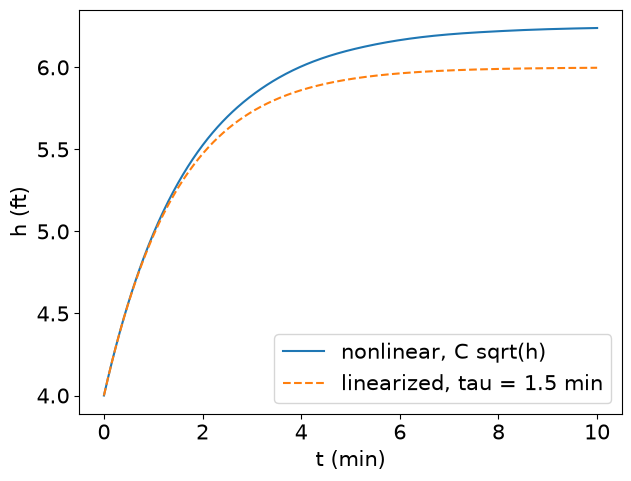

```python
fig, ax = plt.subplots(figsize=(7, 5.25))
ax.plot(tt, h_nl, label="nonlinear, C sqrt(h)")
ax.plot(tt, h_lin, "--", label="linearized, tau = 1.5 min")
ax.set(xlabel="t (min)", ylabel="h (ft)")
ax.legend(loc="lower right")
plt.show()
```

**Code walkthrough.** Two curves on one axis, the linearized one dashed. Both start at 4 ft with the same initial slope -- the tangent is exact at the operating point -- and separate as the level moves away from h_s (cf. Fig. 5-9).

### Build on it -- where is the tangent good enough?

- Steady state: true $h = (q/C)^2$; tangent $h = h_s + R_1(q-q_s)$
- Find the inflows where they differ by less than 5%

```python
q = np.linspace(4, 32, 281)            # candidate inflows, cfm
h_true = (q / 8) ** 2                  # nonlinear steady state
h_tan = 4 + R1_val * (q - 16)          # the tangent line
err = 100 * (h_tan - h_true) / h_true  # percent error
ok = np.abs(err) < 5
print(f"within 5%: q from {q[ok].min():.1f} "
      f"to {q[ok].max():.1f} cfm")
```

```
within 5%: q from 13.1 to 20.6 cfm
```

**Code walkthrough.** `q` is a grid of 281 candidate inflows. For each, the true steady level (q/C)^2 and the tangent's level h_s + R1(q - q_s) are computed in one line each; `err` is the percentage error. `ok` is a boolean array (True where |err| < 5%); `q[ok].min()` and `.max()` give the window edges. Prints 13.1 to 20.6 cfm.

### Plot -- the curve, its tangent, and the validity window

- Shaded: error under 5%
- Outside it, the linear model drifts

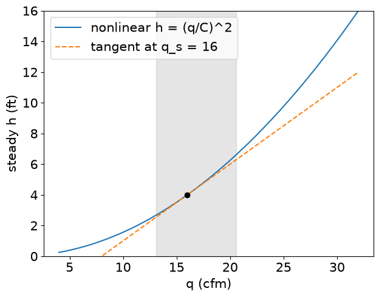

```python
fig, ax = plt.subplots(figsize=(7, 5.25))
ax.plot(q, h_true, label="nonlinear h = (q/C)^2")
ax.plot(q, h_tan, "--", label="tangent at q_s = 16")
ax.axvspan(q[ok].min(), q[ok].max(), color="gray", alpha=0.2)
ax.plot(16, 4, "ko")                    # operating point
ax.set(xlabel="q (cfm)", ylabel="steady h (ft)", ylim=(0, 16))
ax.legend(loc="upper left")
plt.show()
```

**Code walkthrough.** The nonlinear steady-state curve, its tangent at q_s = 16 cfm (dashed), the operating point (black dot) and, shaded with `axvspan`, the inflows where the tangent is within 5%. Outside the band the linear model drifts away.

### Read the output

- Exact at $h_s$, good nearby, wrong far away: a **validity window**.
- Adequate when a controller holds $h$ near $h_s$ (Sec. 5.2).
- Every model -- transfer function, regression, neural net -- has a window. **Do you know where its edges are?**

Window algebra (Derivations notebook): with x = q/qs, relative error = -(x-1)^2/x^2, so |err| < 5% for x in [0.817, 1.288], i.e. q in [13.1, 20.6] cfm. The book's own +4 cfm step (to 20) sits right at the edge -- which is why Fig. 5-9 shows a visible but modest gap. Bridge: this is the same question we will ask of ML surrogates in L11.

### Your Turn (8 min)

**Prob. 5.2.** Tank with $A = 3$ ft$^2$ and valve $q = 8\sqrt{h}$.

1. By hand: $\tau$ at an operating level of (a) 3 ft, (b) 9 ft.
2. Read the code: what does this print?

```
print(3 * float(R1.subs({Cv: 8, hs: 9})))
```

tau = R1 A = 2 A sqrt(h_s)/C. (a) 2(3)(1.732)/8 = 1.30 min. (b) 2(3)(3)/8 = 2.25 min. (2) Prints 2.25: R1 at h_s = 9 ft is 0.75 ft/cfm, times A = 3 ft^2. Same tank, same valve, different tau: the dynamics depend on where you operate. A controller tuned at 3 ft is tuned for a different process than the one at 9 ft (gain scheduling). Slip: using C = 8 with h instead of sqrt(h).

### Check -- poll

Now step the inflow **down**, 16 to 12 cfm. The linear model's final level is:

**A)** too high **B)** too low **C)** exactly right

B, too low: linear gives 4 - 0.5(4) = 2.00 ft; true (12/8)^2 = 2.25 ft. Same side as the +4 step (6.00 vs 6.25). Reason: h = (q/C)^2 is convex, so the tangent lies below the curve everywhere. Rerun the simulation cell with args=(12.0,) and 4 * G_lin -> -4 * G_lin to show it.

## Part D

### Tanks in Series: Interaction and Transfer Lag

(Coughanowr & LeBlanc, Ch. 6)

### Introduce -- two tanks, two ways to connect them

- **Noninteracting:** tank 1 drains freely, $q_1 = h_1/R_1$.
- **Interacting:** tank 1 drains *into* tank 2, $q_1 = (h_1-h_2)/R_1$.
- One term differs. **Does it change the dynamics?**

*Textbook figure: Coughanowr Fig. 6-1 ((a) noninteracting, (b) interacting tanks).*

### Derive 1/3 -- the four equations, in $s$

Two balances, two valves (deviation variables, Eqs. 6.20-6.23):

$$Q - Q_1 = A_1 s H_1, \qquad Q_1 - Q_2 = A_2 s H_2$$ $$R_1 Q_1 = H_1 - H_2, \qquad R_2 Q_2 = H_2$$

Noninteracting: the third equation is $R_1 Q_1 = H_1$ instead.

### Derive 2/3 -- noninteracting: the blocks multiply

Each tank sees only what flows in (Eq. 6.7):

$$\frac{H_2}{Q} = \frac{1}{\tau_1 s+1}\cdot\frac{R_2}{\tau_2 s+1}, \qquad \tau_i = A_i R_i$$

### Derive 3/3 -- interacting: eliminate $H_1, Q_1, Q_2$

Tank 1 now feels $H_2$; the result does **not** factor (Eq. 6.24):

$$\frac{H_2}{Q} = \frac{R_2}{\tau_1\tau_2 s^2 + (\tau_1+\tau_2+A_1R_2)\,s + 1}$$

The extra $A_1R_2$ is the interaction.

The elimination is three lines of substitution; the full version is in the Derivations notebook. Do it on the board only as far as students need to see where A1 R2 comes from: it enters through H1 = H2 + R1 Q1.

### Code 1/2 -- four equations, solved at once

- The four board equations, typed as written
- `sp.solve` eliminates $H_1, Q_1, Q_2$ in one call

```python
Q, Q1, Q2, H1, H2 = sp.symbols("Q Q1 Q2 H1 H2")
A1, A2, R1, R2 = sp.symbols("A1 A2 R1 R2", positive=True)
eqs = [sp.Eq(Q - Q1, A1*s*H1),       # tank 1 balance
       sp.Eq(Q1 - Q2, A2*s*H2),      # tank 2 balance
       sp.Eq(R1*Q1, H1 - H2),        # interacting valve
       sp.Eq(R2*Q2, H2)]             # outlet valve
sol = sp.solve(eqs, [Q1, Q2, H1, H2], dict=True)[0]
G_int = sp.simplify(sol[H2] / Q)
G_int
```

$\displaystyle \frac{R_{2}}{A_{1} A_{2} R_{1} R_{2} s^{2} + A_{1} R_{1} s + A_{1} R_{2} s + A_{2} R_{2} s + 1}$

**Code walkthrough.** Q, Q1, Q2, H1, H2 are the five Laplace-domain unknowns; A1, A2, R1, R2 the parameters. `eqs` is the list of the four board equations, typed as written (Eqs. 6.20-6.23). `sp.solve(eqs, [Q1, Q2, H1, H2], dict=True)` eliminates everything except Q; `[0]` takes the solution dictionary. `sol[H2] / Q` is the transfer function. The display shows R2/(A1 A2 R1 R2 s^2 + (A1 R1 + A1 R2 + A2 R2)s + 1): Eq. 6.24 with tau1 = A1 R1 and tau2 = A2 R2.

### Code 2/2 -- change one line: noninteracting

- Replace the valve equation by $R_1Q_1 = H_1$
- `sp.factor` shows the product of two first-order blocks

```python
eqs[2] = sp.Eq(R1*Q1, H1)            # noninteracting valve
sol = sp.solve(eqs, [Q1, Q2, H1, H2], dict=True)[0]
G_non = sp.factor(sol[H2] / Q)
G_non                                # R2 / ((A1R1 s+1)(A2R2 s+1))
```

$\displaystyle \frac{R_{2}}{\left(A_{1} R_{1} s + 1\right) \left(A_{2} R_{2} s + 1\right)}$

**Code walkthrough.** `eqs[2] = ...` replaces only the valve equation (index 2, the third item) with the noninteracting law R1 Q1 = H1, and the same `solve` runs again. `sp.factor` writes the result as R2/((A1 R1 s + 1)(A2 R2 s + 1)): the product of two first-order blocks, Eq. 6.7. One changed equation, one changed physical arrangement.

### Build on it -- which one responds faster?

- Identical tanks: $A_1=A_2=R_1=R_2=1$, so $\tau_1=\tau_2=1$.
- Plug in, get **numbers**, compare poles and step responses.

### Poles from the derived transfer functions

- `.subs` puts in the numbers; `sp.fraction` splits num / den
- `sp.Poly(...).all_coeffs()` gives the list `ct.tf` wants

```python
one = {A1: 1, A2: 1, R1: 1, R2: 1}
tfs = {}
for name, G in [("non", G_non), ("int", G_int)]:
    num, den = sp.fraction(sp.together(G.subs(one)))
    c = [float(v) for v in sp.Poly(den, s).all_coeffs()]
    tfs[name] = ct.tf([float(num)], c)
    print(name, c, "poles:", np.round(ct.poles(tfs[name]).real, 3))
```

```
non [1.0, 2.0, 1.0] poles: [-1. -1.]
int [1.0, 3.0, 1.0] poles: [-2.618 -0.382]
```

**Code walkthrough.** `one` sets every parameter to 1. For each derived transfer function: `sp.together` puts it over one denominator, `sp.fraction` splits it into numerator and denominator, `sp.Poly(den, s).all_coeffs()` lists the denominator coefficients (highest power first) -- the format `ct.tf` wants. Prints non [1, 2, 1] with poles -1, -1 and int [1, 3, 1] with poles -2.618, -0.382. The slow pole at -0.382 (time constant 2.618) is why the interacting system is slower.

### Simulate the tanks directly, as ODEs

- One function, both arrangements: a flag picks the valve law
- Two coupled states in one `solve_ivp`: a **state-space** model

```python
def two_tanks(t, h, interacting):
    h1, h2 = h
    q1 = (h1 - h2) if interacting else h1   # R1 = 1
    return [1.0 - q1, q1 - h2]              # A = R2 = 1, q = 1

tt = np.linspace(0, 10, 400)
h2 = {}
for mode in (False, True):
    h2[mode] = solve_ivp(two_tanks, [0, 10], [0, 0],
                         args=(mode,), t_eval=tt).y[1]
```

**Code walkthrough.** `two_tanks` is the four equations in the time domain with A = R = 1 and a unit inflow. The flag `interacting` chooses the valve law with a conditional expression. The loop runs `solve_ivp` twice, from empty tanks, and stores h2 for each mode in a dictionary keyed by the flag. Two coupled states integrated together: a state-space model (Lecture 12).

### Plot -- ODE versus derived transfer functions (cf. Fig. 6-7)

- Thick: ODE simulation. Dotted: the transfer functions we derived
- The ODE never saw a transfer function, yet matches both

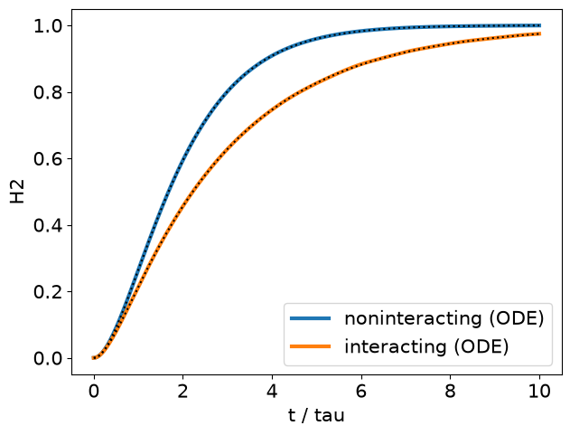

```python
fig, ax = plt.subplots(figsize=(7, 5.25))
ax.plot(tt, h2[False], lw=3, label="noninteracting (ODE)")
ax.plot(tt, h2[True], lw=3, label="interacting (ODE)")
for G in tfs.values():
    ax.plot(tt, ct.step_response(G, tt).outputs, "k:")
ax.set(xlabel="t / tau", ylabel="H2")
ax.legend(loc="lower right")
plt.show()
```

**Code walkthrough.** Thick lines: the ODE simulations. Dotted lines: step responses of the two transfer functions built from SymPy's results. They coincide: board algebra, SymPy elimination and direct simulation agree. The interacting curve rises more slowly -- rising h2 throttles q1 (the second tank loads the first).

### Build on it -- more tanks in series (cf. Figs. 6-5, 6-6)

- Noninteracting: just keep multiplying blocks
- Watch the start of the curve flatten: **transfer lag**

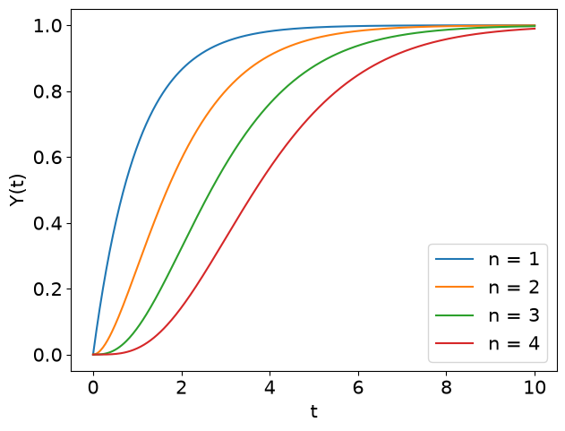

```python
fig, ax = plt.subplots(figsize=(7, 5.25))
G = ct.tf([1], [1])
for n in range(1, 5):
    G = G * ct.tf([1], [1, 1])        # add one tank, tau = 1
    ax.plot(tt, ct.step_response(G, tt).outputs, label=f"n = {n}")
ax.set(xlabel="t", ylabel="Y(t)")
ax.legend(loc="lower right")
plt.show()
```

**Code walkthrough.** `G` starts as 1 and is multiplied by 1/(s + 1) once per pass: after n passes it is n identical noninteracting lags in series (Eq. 6.12). Each response is plotted with its n. As n grows the start of the curve flattens -- transfer lag -- and the curve starts to look like a delay followed by a single lag: the FOPDT idea of Lecture 4.

### Your Turn (8 min)

Interacting tanks with $\tau_1=\tau_2=\tau$ and $A_1=A_2$ (so $A_1R_2=\tau$).

1. By hand: show the denominator of Eq. 6.24 becomes $\tau^2 s^2 + 3\tau s + 1$.
2. By hand: its roots, and the two effective time constants.
3. Read the code: what do these print?

```
print(np.roots([1, 3, 1]))
print(-1 / np.roots([1, 3, 1]))
```

(1) tau1 tau2 = tau^2 ; tau1 + tau2 + A1 R2 = tau + tau + tau = 3 tau. (2) s = (-3 +/- sqrt(5)) / (2 tau) = -0.382/tau, -2.618/tau. Effective time constants = -1/root = 2.618 tau and 0.382 tau (product tau^2, sum 3 tau). Eq. 6.28. (3) [-2.618 -0.382] and [0.382 2.618]: the roots, and the effective time constants as -1/root. Aside: 2.618 = phi^2, 0.382 = 1/phi^2 (golden ratio).

### Check -- cold-call

Four tanks in series. You only have the **measured** $h_4(t)$.

What is the simplest model you would fit -- and what would its parameters mean physically?

First-order-plus-dead-time (FOPDT), K e^{-theta s}/(tau s + 1): theta absorbs the transfer lag of the upstream tanks, tau the dominant lag, K the gain. It is Part B's curve_fit with one more parameter. Sets up Ch. 7 (transportation lag, next lecture) and Ch. 18.

### Wrap-up

**Derived, then coded:** thermometer transfer function and its step and sinusoidal responses (Ch. 4); $\tau$ from data by least squares (Prob. 4.6); linearization and its validity window (Ch. 5); interacting versus noninteracting tanks (Ch. 6).

**Tools:** `sp.laplace_transform`, `sp.apart`, `sp.solve`, `lambdify`, `ct.tf`, `step_response`, `solve_ivp`, `curve_fit`

**Next:** Ch. 7 -- transportation lag and second-order systems.

Optional practice (ungraded): Prob. 5.7 gives steady-state level versus inflow for a real tank. Fit q = K h^n with curve_fit, then linearize the fitted valve at 300 and 400 gal/min and compare tau. Part B + Part C on real data -- a good warm-up for Assignment 1.